# Ej01 sol

## Ejercicio 1

El cometa Tentax, descubierto en 1968, viaja por nuestro sistema solar. Las siguientes observaciones dan su posición con respecto a un sistema de coordenadas polar $\left(r,\alpha\right)$.

$$ \begin{array}{|c|c|c|c|c|c|} \hline r & 13.5 & 10 & 8 & 6 & 5.1\\ \hline \hline \alpha & 48^{o} & 67{}^{o} & 83^{o} & 108^{o} & 126{}^{o}\\ \hline \end{array} $$

Despreciando las perturbaciones inducidas por los planetas, si de acuerdo con la Primera Ley de Kepler, la órbita aproximada es de la forma

$$ r=\frac{a}{1-b\cos\left(\alpha\right)} $$

que representa una elipse o una hipérbola. Calcular los valores de $a$ y $b$ utilizando el método de minimización de errores cuadráticos.

Vamos a utilizar aproximación lineal con mínimos cuadrados. Pero para ello necesitamos, primero, linealizar la función a ajustar. Para un punto cualquiera, debería cumplirse, aproximadamente

$$ r_k=\frac{a}{1-b\cos\left(\alpha_k\right)} \quad \Longrightarrow \quad \frac{1}{r_k}=\frac{1-b\cos\left(\alpha_k\right)}{a} \quad \Longrightarrow \quad \frac{1}{r_k}=\frac{1}{a}-\frac{b}{a}\,\cos\left(\alpha_k\right) $$

Y si llamamos $$ y_k = \frac{1}{r_k}, \quad x_k =\cos\left(\alpha_k\right), \quad a_0 =\frac{1}{a}, \quad a_1=-\frac{b}{a} $$

tenemos

$$ \frac{1}{r_k}=\frac{1}{a}-\frac{b}{a}\,\cos\left(\alpha_k\right) \quad \Longrightarrow \quad y_k = a_0 + a_1\, x_k $$

el problema es ahora ajustar una recta de regresión mínimo cuadrática

$$ P_1(x) = a_0 + a_1\, x $$

a los datos transformado $(x_k,y_k),\quad k = 1,\ldots,5$ con el sistema del ejercicio anterior.

$$ \left(\begin{array}{cc} \sum_{k=1}^{5}1 & \sum_{k=1}^{5}x_{k}\\ \sum_{k=1}^{5}x_{k} & \sum_{k=1}^{5}x_{k}^{2} \end{array}\right)\left(\begin{array}{c} a_{0}\\ a_{1} \end{array}\right)=\left(\begin{array}{c} \sum_{k=1}^{5}y_{k}\\ \sum_{k=1}^{5}x_{k}y_{k} \end{array}\right) $$

Entonces

$$ a_0 =\frac{1}{a} \quad a_1=-\frac{b}{a}\quad \Longrightarrow a=\frac{1}{a_0} \quad b=- a_1\times a $$

Usar **`plt.polar(alfa,r)`** para representar los puntos y la solución final.

```python
%matplotlib inline
import numpy as np
import matplotlib.pyplot as plt
```

Transformamos las variables.

```python
r = np.array([13.5, 10., 8., 6., 5.1])
alfa = np.array([48., 67., 83., 108., 126.])
y = 1./r
x = np.cos(alfa/180.*np.pi) # los ángulos, en radianes
```

En este caso, planteamos el sistema usando la matriz de Vandermonde

```python
g = 1      # grado del polinomio de aproximación
m = len(x) # ńumero de puntos
v = np.ones((m,g+1))
v[:,1] = x

A = np.dot(v.T,v)
b = np.dot(v.T,y)
coef = np.linalg.solve(A,b)

print(coef)
```

```
[ 0.13787593 -0.09672754]
```

Y tenemos $a_0 = 0.138 \quad a_1=-0.0967$. Como

$$ a_0 =\frac{1}{a} \quad a_1=-\frac{b}{a}\quad \Longrightarrow a=\frac{1}{a_0} \quad b=- a_1\times a $$

```python
a = 1./coef[0]
b =  -coef[1]*a
print ('a = ', a, ' b = ',b)
```

```
a =  7.25289773771  b =  0.701554920549
```

$$ r=\frac{7.25}{1-0.702\cos\left(\alpha\right)} $$

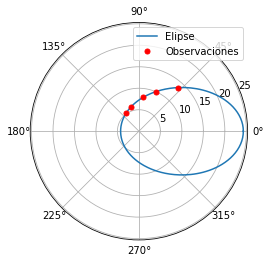

```python
# Elipse
alf = np.linspace(0.,2*np.pi,200)
rr = a/(1-b*np.cos(alf))
plt.polar(alf,rr,label='Elipse')
# nodos
plt.polar(alfa/180.*np.pi,r,'r.',markersize=10,label='Observaciones')

plt.legend(loc='best')
plt.show()
```